# **Exploratory Analysis Report**

TheDataAreClean

25th March, ’20

### **Objective**

Exploratory analysis of the data to unsterstand the composition and trends of the budget expenditure and district spending data.

### **Read**

Read the combined and cleaned state expenditure and district spending datasets for exploratory analysis.

```r
# State expenditure data
budget_exp_final <- read_csv("../data/processed/budget_exp_final.csv")

# Distirct spending data
district_spending_exp_final <- read_csv("../data/processed/district_spending_exp_final.csv")
```

### **Analysis**

#### **State Budget Expenditure**

##### **Overall**

```r
# Quick Summary
budget_exp_final %>%
    group_by(year) %>%
    summarise(sanction = sum(sanction),
              addition = sum(addition),
              savings = sum(savings),
              revised = sum(revised))
```

```
## # A tibble: 2 x 5
##   year       sanction   addition    savings     revised
##   <chr>         <dbl>      <dbl>      <dbl>       <dbl>
## 1 2017-18 1394299171. 259944273. 298928835. 1355314609.
## 2 2018-19 1596963894. 216523534. 295669140. 1517818288.
```

- The sanctioned budget amount for Himachal Pradesh in 2018-19 was 159.7 Cr., a 14.5% increase over the previous years budget.
- Post revisions, the allocated amount went down to 97.2% of the sanctions allocated in the year 2017-18, and 95% in the year 2018-19.

##### **Top Major Account Heads**

```r
# Account Head Wise spending
budget_exp_final %>%
    group_by(year, demand_desc) %>%
    summarise(sanction = sum(sanction)) %>%
    spread(year, sanction, fill = 0) %>%
    arrange(desc(`2018-19`)) %>%
    mutate(`Total Sanction (2018-19)` = sum(`2018-19`),
           `Total Sanction (2017-18)` = sum(`2017-18`)) %>%
    mutate(`% of Expenditure (2018-19)` = percent(`2018-19`/`Total Sanction (2018-19)`),
           `% of Expenditure (2017-18)` = percent(`2017-18`/`Total Sanction (2017-18)`)) %>%
    select(demand_desc, `2018-19`, `% of Expenditure (2018-19)`, `2017-18`, `% of Expenditure (2017-18)`)
```

```
## # A tibble: 32 x 5
##    demand_desc         `2018-19` `% of Expenditure… `2017-18` `% of Expenditure…
##    <chr>                   <dbl> <formttbl>             <dbl> <formttbl>
##  1 FINANCE            486955526. 30.49%                4.25e8 30.50%
##  2 EDUCATION          225519140. 14.12%                1.99e8 14.28%
##  3 PUBLIC WORKS – RO… 163781126. 10.26%                1.42e8 10.21%
##  4 IRRIGATION WATER … 111868932. 7.01%                 1.00e8 7.20%
##  5 SCHEDULED CASTES …  87294218. 5.47%                 7.89e7 5.66%
##  6 HEALTH AND FAMILY…  78952385. 4.94%                 6.09e7 4.37%
##  7 TRIBAL DEVELOPMENT  58640373. 3.67%                 5.26e7 3.77%
##  8 RURAL DEVELOPMENT   56816396. 3.56%                 4.73e7 3.39%
##  9 POLICE AND ALLIED…  49849865. 3.12%                 4.22e7 3.03%
## 10 LAND REVENUE AND …  34883127. 2.18%                 3.25e7 2.33%
## # … with 22 more rows
```

- Finance was alloyed the highest amount of all account heads, 30.49% of total sanctioned expenditure for the year; followed by Education with 14.12% & Public Works – Roads Bridges & Buildings at 10.26%
- This trend has followed form 2017-18 in terms of priority for the state budget allocations.

##### **Allocations Over Time**

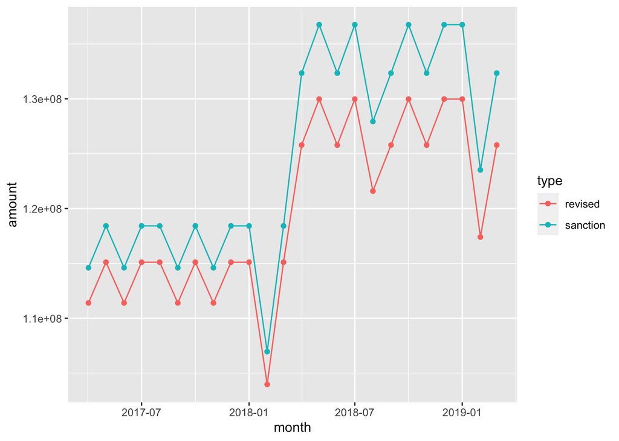

```r
# Trends for budget allocation over time
budget_exp_final %>%
    mutate(month = floor_date(transaction_date, unit = "month")) %>%
    group_by(month) %>%
    summarise(sanction = sum(sanction),
              revised = sum(revised)) %>%
    gather(type, amount, -month) %>%
    ggplot(aes(x = month, y = amount, color = type)) +
    geom_line() + geom_point()
```

- Looking at the time trends data, the impression recieved is that budgets and revisions are done with the intent to distribute the aloocations at a dataily basis on the projected price.
- It will be interesting to compare it against the spending data to see the spending trends on ground.

##### **Voted/Charged & Plan/Non-Plan**

```r
# Voted/Charged
budget_exp_final %>%
    group_by(year, voted_charged) %>%
    summarise(sanction = sum(sanction)) %>%
    spread(voted_charged, sanction) %>%
    mutate(percent_charged = percent(C/(V+C)),
           percent_voted = percent(V/(V+C)))
```

```
## # A tibble: 2 x 5
## # Groups:   year [2]
##   year             C           V percent_charged percent_voted
##   <chr>        <dbl>       <dbl>           <dbl>         <dbl>
## 1 2017-18 243019989. 1151279182.           0.174         0.826
## 2 2018-19 271769896. 1325193998.           0.170         0.830
```

```r
# Plan/Non-Plan
budget_exp_final %>%
    group_by(year, plan_nonplan) %>%
    summarise(sanction = sum(sanction)) %>%
    spread(plan_nonplan, sanction) %>%
    mutate(percent_non_plan = percent(N/(N+P)),
           percent_plan = percent(P/(N+P)))
```

```
## # A tibble: 2 x 5
## # Groups:   year [2]
##   year              N          P percent_non_plan percent_plan
##   <chr>         <dbl>      <dbl>            <dbl>        <dbl>
## 1 2017-18 1078086623. 316212549.            0.773        0.227
## 2 2018-19 1249071849. 347892046.            0.782        0.218
```

- ~83% of all budgetary allocation in Himachal Pradesh in Voted, remaining ~17% charged.
- ~78% of all budgetary allocation is non-plan expense, and remaning ~22% planned.

##### **2018-19 vs 2017-18**

```r
# Overall Top 10 Investments
# Absolute change in account heads expenditure
budget_exp_final %>%
    group_by(year, demand_desc) %>%
    summarise(sanction = sum(sanction)) %>%
    spread(year, sanction, fill = 0) %>%
    mutate(delta = `2018-19` - `2017-18`,
          percent_delta = percent((`2018-19` - `2017-18`)/`2017-18`)) %>%
    arrange(desc(delta))
```

```
## # A tibble: 32 x 5
##    demand_desc                        `2017-18` `2018-19`    delta percent_delta
##    <chr>                                  <dbl>     <dbl>    <dbl> <formttbl>
##  1 FINANCE                           425260770     4.87e8   6.17e7 14.51%
##  2 EDUCATION                         199041424.    2.26e8   2.65e7 13.30%
##  3 PUBLIC WORKS – ROADS BRIDGES AND… 142395227.    1.64e8   2.14e7 15.02%
##  4 HEALTH AND FAMILY WELFARE          60916054.    7.90e7   1.80e7 29.61%
##  5 IRRIGATION WATER SUPPLY AND SANI… 100391009.    1.12e8   1.15e7 11.43%
##  6 RURAL DEVELOPMENT                  47294061.    5.68e7   9.52e6 20.13%
##  7 SCHEDULED CASTES SUB PLAN          78862721.    8.73e7   8.43e6 10.69%
##  8 POLICE AND ALLIED ORGANISATIONS    42242786.    4.98e7   7.61e6 18.01%
##  9 SOCIAL JUSTICE AND EMPOWERMENT     26986133.    3.42e7   7.20e6 26.70%
## 10 TRIBAL DEVELOPMENT                 52551901.    5.86e7   6.09e6 11.59%
## # … with 22 more rows
```

```r
# % change in account heads expenditure
budget_exp_final %>%
    group_by(year, demand_desc) %>%
    summarise(sanction = sum(sanction)) %>%
    spread(year, sanction, fill = 0) %>%
    mutate(delta = `2018-19` - `2017-18`,
          percent_delta = percent((`2018-19` - `2017-18`)/`2017-18`)) %>%
    arrange(desc(percent_delta))
```

```
## # A tibble: 32 x 5
##    demand_desc                         `2017-18` `2018-19`   delta percent_delta
##    <chr>                                   <dbl>     <dbl>   <dbl> <formttbl>
##  1 TOURISM AND CIVIL AVIATION           2778409.  4496543.  1.72e6 61.84%
##  2 INDUSTRIES MINERALS SUPPLIES AND I…  5939393.  9073443.  3.13e6 52.77%
##  3 AGRICULTURE                         15018567. 20131309.  5.11e6 34.04%
##  4 HEALTH AND FAMILY WELFARE           60916054. 78952385.  1.80e7 29.61%
##  5 VIDHAN SABHA                         1244095.  1609380.  3.65e5 29.36%
##  6 SOCIAL JUSTICE AND EMPOWERMENT      26986133. 34190332.  7.20e6 26.70%
##  7 RURAL DEVELOPMENT                   47294061. 56816396.  9.52e6 20.13%
##  8 GENERAL ADMINISTRATION               6606993.  7909255.  1.30e6 19.71%
##  9 ADMINISTRATION OF JUSTICE            7488300.  8922721.  1.43e6 19.16%
## 10 FOREST AND WILD LIFE                16847688. 20033822.  3.19e6 18.91%
## # … with 22 more rows
```

```r
# Overall Top 10 Disinvestments
# Absolute change in account heads expenditure
budget_exp_final %>%
    group_by(year, demand_desc) %>%
    summarise(sanction = sum(sanction)) %>%
    spread(year, sanction, fill = 0) %>%
    mutate(delta = `2018-19` - `2017-18`,
          percent_delta = percent((`2018-19` - `2017-18`)/`2017-18`)) %>%
    arrange(delta)
```

```
## # A tibble: 32 x 5
##    demand_desc                        `2017-18` `2018-19`    delta percent_delta
##    <chr>                                  <dbl>     <dbl>    <dbl> <formttbl>
##  1 LABOUR EMPLOYMENT AND TRAINING     17049464. 13095969.  -3.95e6 -23.19%
##  2 ELECTION                            1442626    900435.  -5.42e5 -37.58%
##  3 GOVERNOR AND COUNCIL OF MINISTERS    766558.   786007.   1.94e4 2.54%
##  4 PRINTING AND STATIONERY              959490.  1026672.   6.72e4 7.00%
##  5 COOPERATION                         1081426.  1212790.   1.31e5 12.15%
##  6 VIDHAN SABHA                        1244095.  1609380.   3.65e5 29.36%
##  7 EXCISE AND TAXATION                 2598231.  3006996.   4.09e5 15.73%
##  8 MISCELLANEOUS GENERAL SERVICES      4672040.  5088102.   4.16e5 8.91%
##  9 PLANNING AND BACKWARD AREA SUB-PL… 11612997. 12329420.   7.16e5 6.17%
## 10 FOOD AND CIVIL SUPPLIES             8820966.  9539710.   7.19e5 8.15%
## # … with 22 more rows
```

```r
# Absolute change in account heads expenditure
budget_exp_final %>%
    group_by(year, demand_desc) %>%
    summarise(sanction = sum(sanction)) %>%
    spread(year, sanction, fill = 0) %>%
    mutate(delta = `2018-19` - `2017-18`,
          percent_delta = percent((`2018-19` - `2017-18`)/`2017-18`)) %>%
    arrange(percent_delta)
```

```
## # A tibble: 32 x 5
##    demand_desc                        `2017-18` `2018-19`    delta percent_delta
##    <chr>                                  <dbl>     <dbl>    <dbl> <formttbl>
##  1 ELECTION                            1442626    900435.  -5.42e5 -37.58%
##  2 LABOUR EMPLOYMENT AND TRAINING     17049464. 13095969.  -3.95e6 -23.19%
##  3 GOVERNOR AND COUNCIL OF MINISTERS    766558.   786007.   1.94e4 2.54%
##  4 POWER DEVELOPMENT                  33187603. 34256813.   1.07e6 3.22%
##  5 PLANNING AND BACKWARD AREA SUB-PL… 11612997. 12329420.   7.16e5 6.17%
##  6 PRINTING AND STATIONERY              959490.  1026672.   6.72e4 7.00%
##  7 LAND REVENUE AND DISTRICT ADMINIS… 32539338. 34883127.   2.34e6 7.20%
##  8 FOOD AND CIVIL SUPPLIES             8820966.  9539710.   7.19e5 8.15%
##  9 MISCELLANEOUS GENERAL SERVICES      4672040.  5088102.   4.16e5 8.91%
## 10 SCHEDULED CASTES SUB PLAN          78862721. 87294218.   8.43e6 10.69%
## # … with 22 more rows
```

##### **Estimates vs Revisions**

```r
## Estimates to Revision
## 2017-18 positive absolute change
budget_exp_final %>%
    filter(year == "2017-18") %>%
    group_by(demand_desc) %>%
    summarise(sanction = sum(sanction),
              revised = sum(revised)) %>%
    mutate(revision_delta = (revised - sanction),
           percent_delta =  percent((revised - sanction)/sanction)) %>%
    arrange(desc(revision_delta))
```

```
## # A tibble: 32 x 5
##    demand_desc                    sanction  revised revision_delta percent_delta
##    <chr>                             <dbl>    <dbl>          <dbl> <formttbl>
##  1 IRRIGATION WATER SUPPLY AND …    1.00e8   1.05e8       4973045. 4.95%
##  2 FINANCE                          4.25e8   4.30e8       4279592. 1.01%
##  3 ROAD AND WATER TRANSPORT         9.98e6   1.34e7       3465547. 34.73%
##  4 HEALTH AND FAMILY WELFARE        6.09e7   6.39e7       2944842. 4.83%
##  5 PLANNING AND BACKWARD AREA S…    1.16e7   1.38e7       2142094. 18.45%
##  6 COOPERATION                      1.08e6   3.08e6       1996535. 184.62%
##  7 TOURISM AND CIVIL AVIATION       2.78e6   4.64e6       1858901. 66.91%
##  8 SOCIAL JUSTICE AND EMPOWERME…    2.70e7   2.86e7       1607551. 5.96%
##  9 LAND REVENUE AND DISTRICT AD…    3.25e7   3.35e7        951066. 2.92%
## 10 ELECTION                         1.44e6   2.27e6        826415. 57.29%
## # … with 22 more rows
```

```r
## 2017-18 positive percent change
budget_exp_final %>%
    filter(year == "2017-18") %>%
    group_by(demand_desc) %>%
    summarise(sanction = sum(sanction),
              revised = sum(revised)) %>%
    mutate(revision_delta = (revised - sanction),
           percent_delta =  percent((revised - sanction)/sanction)) %>%
    arrange(desc(percent_delta))
```

```
## # A tibble: 32 x 5
##    demand_desc                    sanction  revised revision_delta percent_delta
##    <chr>                             <dbl>    <dbl>          <dbl> <formttbl>
##  1 COOPERATION                    1081426.   3.08e6       1996535. 184.62%
##  2 TOURISM AND CIVIL AVIATION     2778409.   4.64e6       1858901. 66.91%
##  3 ELECTION                       1442626    2.27e6        826415. 57.29%
##  4 ROAD AND WATER TRANSPORT       9979655.   1.34e7       3465547. 34.73%
##  5 PLANNING AND BACKWARD AREA S… 11612997.   1.38e7       2142094. 18.45%
##  6 MISCELLANEOUS GENERAL SERVIC…  4672040.   5.32e6        644685. 13.80%
##  7 GOVERNOR AND COUNCIL OF MINI…   766558.   8.64e5         97415. 12.71%
##  8 ADMINISTRATION OF JUSTICE      7488300.   8.21e6        722131. 9.64%
##  9 PRINTING AND STATIONERY         959490.   1.05e6         88126. 9.18%
## 10 SOCIAL JUSTICE AND EMPOWERME… 26986133.   2.86e7       1607551. 5.96%
## # … with 22 more rows
```

```r
## 2017-18 negative absolute change
budget_exp_final %>%
    filter(year == "2017-18") %>%
    group_by(demand_desc) %>%
    summarise(sanction = sum(sanction),
              revised = sum(revised)) %>%
    mutate(revision_delta = (revised - sanction),
           percent_delta =  percent((revised - sanction)/sanction)) %>%
    arrange(revision_delta)
```

```
## # A tibble: 32 x 5
##    demand_desc                    sanction  revised revision_delta percent_delta
##    <chr>                             <dbl>    <dbl>          <dbl> <formttbl>
##  1 SCHEDULED CASTES SUB PLAN        7.89e7   6.41e7     -14777631. -18.74%
##  2 RURAL DEVELOPMENT                4.73e7   3.38e7     -13526079. -28.60%
##  3 EDUCATION                        1.99e8   1.88e8     -10616824. -5.33%
##  4 LABOUR EMPLOYMENT AND TRAINI…    1.70e7   9.98e6      -7069090. -41.46%
##  5 TRIBAL DEVELOPMENT               5.26e7   4.57e7      -6824920. -12.99%
##  6 POWER DEVELOPMENT                3.32e7   2.87e7      -4442933. -13.39%
##  7 URBAN DEVELOPMENT TOWN AND C…    1.32e7   9.46e6      -3763114. -28.45%
##  8 FOREST AND WILD LIFE             1.68e7   1.44e7      -2489395. -14.78%
##  9 HORTICULTURE                     1.16e7   9.96e6      -1637124. -14.12%
## 10 ANIMAL HUSBANDARY DAIRY DEVE…    1.29e7   1.13e7      -1607880. -12.46%
## # … with 22 more rows
```

```r
## 2017-18 negative percent change
budget_exp_final %>%
    filter(year == "2017-18") %>%
    group_by(demand_desc) %>%
    summarise(sanction = sum(sanction),
              revised = sum(revised)) %>%
    mutate(revision_delta = (revised - sanction),
           percent_delta =  percent((revised - sanction)/sanction)) %>%
    arrange(percent_delta)
```

```
## # A tibble: 32 x 5
##    demand_desc                    sanction  revised revision_delta percent_delta
##    <chr>                             <dbl>    <dbl>          <dbl> <formttbl>
##  1 LABOUR EMPLOYMENT AND TRAINI…    1.70e7   9.98e6      -7069090. -41.46%
##  2 RURAL DEVELOPMENT                4.73e7   3.38e7     -13526079. -28.60%
##  3 URBAN DEVELOPMENT TOWN AND C…    1.32e7   9.46e6      -3763114. -28.45%
##  4 SCHEDULED CASTES SUB PLAN        7.89e7   6.41e7     -14777631. -18.74%
##  5 FOREST AND WILD LIFE             1.68e7   1.44e7      -2489395. -14.78%
##  6 HORTICULTURE                     1.16e7   9.96e6      -1637124. -14.12%
##  7 POWER DEVELOPMENT                3.32e7   2.87e7      -4442933. -13.39%
##  8 TRIBAL DEVELOPMENT               5.26e7   4.57e7      -6824920. -12.99%
##  9 ANIMAL HUSBANDARY DAIRY DEVE…    1.29e7   1.13e7      -1607880. -12.46%
## 10 EDUCATION                        1.99e8   1.88e8     -10616824. -5.33%
## # … with 22 more rows
```

```r
## 2018-19 positive absolute change
budget_exp_final %>%
    filter(year == "2018-19") %>%
    group_by(demand_desc) %>%
    summarise(sanction = sum(sanction),
              revised = sum(revised)) %>%
    mutate(revision_delta = (revised - sanction),
           percent_delta =  percent((revised - sanction)/sanction)) %>%
    arrange(desc(revision_delta))
```

```
## # A tibble: 32 x 5
##    demand_desc                    sanction  revised revision_delta percent_delta
##    <chr>                             <dbl>    <dbl>          <dbl> <formttbl>
##  1 LAND REVENUE AND DISTRICT AD…    3.49e7   4.94e7      14489694. 41.54%
##  2 FINANCE                          4.87e8   4.95e8       8382910. 1.72%
##  3 IRRIGATION WATER SUPPLY AND …    1.12e8   1.18e8       6249680. 5.59%
##  4 POWER DEVELOPMENT                3.43e7   3.75e7       3228707. 9.43%
##  5 MISCELLANEOUS GENERAL SERVIC…    5.09e6   7.92e6       2835995. 55.74%
##  6 FOOD AND CIVIL SUPPLIES          9.54e6   1.20e7       2421328. 25.38%
##  7 ROAD AND WATER TRANSPORT         1.14e7   1.35e7       2130004. 18.67%
##  8 COOPERATION                      1.21e6   2.52e6       1303385. 107.47%
##  9 TOURISM AND CIVIL AVIATION       4.50e6   5.57e6       1077804. 23.97%
## 10 SOCIAL JUSTICE AND EMPOWERME…    3.42e7   3.52e7       1012319. 2.96%
## # … with 22 more rows
```

```r
## 2018-19 positive percent change
budget_exp_final %>%
    filter(year == "2018-19") %>%
    group_by(demand_desc) %>%
    summarise(sanction = sum(sanction),
              revised = sum(revised)) %>%
    mutate(revision_delta = (revised - sanction),
           percent_delta =  percent((revised - sanction)/sanction)) %>%
    arrange(desc(percent_delta))
```

```
## # A tibble: 32 x 5
##    demand_desc                    sanction  revised revision_delta percent_delta
##    <chr>                             <dbl>    <dbl>          <dbl> <formttbl>
##  1 COOPERATION                      1.21e6   2.52e6       1303385. 107.47%
##  2 ELECTION                         9.00e5   1.57e6        669693. 74.37%
##  3 MISCELLANEOUS GENERAL SERVICES   5.09e6   7.92e6       2835995. 55.74%
##  4 LAND REVENUE AND DISTRICT ADM…   3.49e7   4.94e7      14489694. 41.54%
##  5 FOOD AND CIVIL SUPPLIES          9.54e6   1.20e7       2421328. 25.38%
##  6 TOURISM AND CIVIL AVIATION       4.50e6   5.57e6       1077804. 23.97%
##  7 GOVERNOR AND COUNCIL OF MINIS…   7.86e5   9.40e5        154371. 19.64%
##  8 ROAD AND WATER TRANSPORT         1.14e7   1.35e7       2130004. 18.67%
##  9 POWER DEVELOPMENT                3.43e7   3.75e7       3228707. 9.43%
## 10 VIDHAN SABHA                     1.61e6   1.75e6        138939. 8.63%
## # … with 22 more rows
```

```r
## 2018-19 negative absolute change
budget_exp_final %>%
    filter(year == "2018-19") %>%
    group_by(demand_desc) %>%
    summarise(sanction = sum(sanction),
              revised = sum(revised)) %>%
    mutate(revision_delta = (revised - sanction),
           percent_delta =  percent((revised - sanction)/sanction)) %>%
    arrange(revision_delta)
```

```
## # A tibble: 32 x 5
##    demand_desc                    sanction  revised revision_delta percent_delta
##    <chr>                             <dbl>    <dbl>          <dbl> <formttbl>
##  1 EDUCATION                        2.26e8   1.91e8     -34317557. -15.22%
##  2 SCHEDULED CASTES SUB PLAN        8.73e7   6.82e7     -19131313. -21.92%
##  3 PUBLIC WORKS – ROADS BRIDGES…    1.64e8   1.49e8     -14856371. -9.07%
##  4 TRIBAL DEVELOPMENT               5.86e7   4.45e7     -14115871. -24.07%
##  5 RURAL DEVELOPMENT                5.68e7   4.29e7     -13951180. -24.55%
##  6 HEALTH AND FAMILY WELFARE        7.90e7   6.96e7      -9347720. -11.84%
##  7 POLICE AND ALLIED ORGANISATI…    4.98e7   4.50e7      -4830868. -9.69%
##  8 FOREST AND WILD LIFE             2.00e7   1.53e7      -4772239. -23.82%
##  9 INDUSTRIES MINERALS SUPPLIES…    9.07e6   5.03e6      -4041089. -44.54%
## 10 AGRICULTURE                      2.01e7   1.74e7      -2732448. -13.57%
## # … with 22 more rows
```

```r
## 2018-19 negative percent change
budget_exp_final %>%
    filter(year == "2018-19") %>%
    group_by(demand_desc) %>%
    summarise(sanction = sum(sanction),
              revised = sum(revised)) %>%
    mutate(revision_delta = (revised - sanction),
           percent_delta =  percent((revised - sanction)/sanction)) %>%
    arrange(percent_delta)
```

```
## # A tibble: 32 x 5
##    demand_desc                    sanction  revised revision_delta percent_delta
##    <chr>                             <dbl>    <dbl>          <dbl> <formttbl>
##  1 INDUSTRIES MINERALS SUPPLIES…    9.07e6   5.03e6      -4041089. -44.54%
##  2 RURAL DEVELOPMENT                5.68e7   4.29e7     -13951180. -24.55%
##  3 TRIBAL DEVELOPMENT               5.86e7   4.45e7     -14115871. -24.07%
##  4 FOREST AND WILD LIFE             2.00e7   1.53e7      -4772239. -23.82%
##  5 SCHEDULED CASTES SUB PLAN        8.73e7   6.82e7     -19131313. -21.92%
##  6 EDUCATION                        2.26e8   1.91e8     -34317557. -15.22%
##  7 AGRICULTURE                      2.01e7   1.74e7      -2732448. -13.57%
##  8 HEALTH AND FAMILY WELFARE        7.90e7   6.96e7      -9347720. -11.84%
##  9 POLICE AND ALLIED ORGANISATI…    4.98e7   4.50e7      -4830868. -9.69%
## 10 EXCISE AND TAXATION              3.01e6   2.73e6       -274063. -9.11%
## # … with 22 more rows
```

- Irrigation Water Supply and Sanitation & Finance saw one of the highest increase from sanctions to revisons in both 2017-18 & 2018-19.
- Both financial years saw over huge increases in election expenditure from sanctions to revised, 57.29% in 2017-18 and 74.37% in 2018-19
- Education, Scheduled Castes Sub Plan, Rural Developement, Tribal Developement saw one of the highest decrease from sanctions to revisons in both 2017-18 & 2018-19.

#### **District Spending**

##### **Overall**

```r
# Quick Summary
district_spending_exp_final %>%
    group_by(year) %>%
    summarise(gross = sum(gross),
              adged = sum(agded),
              btded = sum(btded),
              net_payment = sum(net_payment))
```

```
## # A tibble: 2 x 5
##   year           gross       adged       btded  net_payment
##   <chr>          <dbl>       <dbl>       <dbl>        <dbl>
## 1 2017-18 338610175775 28228054766 16761471879 293619324130
## 2 2018-19 374539373671 26975570514 16676189784 330887593373
```

##### **Allocations Over Time**

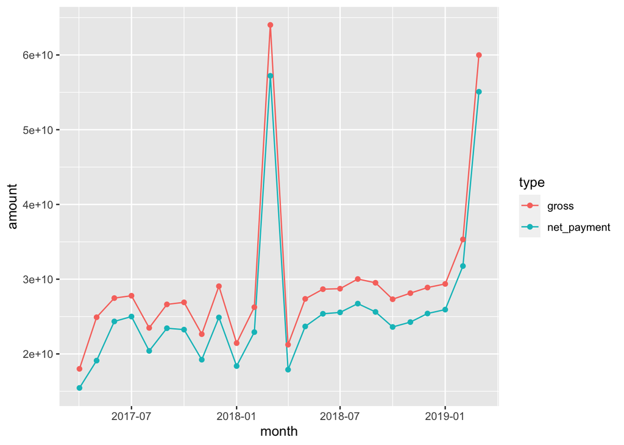

```r
# Trends for budget allocation over time
district_spending_exp_final %>%
    mutate(month = floor_date(transaction_date, unit = "month")) %>%
    group_by(month) %>%
    summarise(gross = sum(gross),
              net_payment = sum(net_payment)) %>%
    gather(type, amount, -month) %>%
    ggplot(aes(x = month, y = amount, color = type)) +
    geom_line() + geom_point()
```

##### **Top Districts & Treasuries**

```r
# District Wise spending
district_spending_exp_final %>%
    group_by(year, district) %>%
    summarise(net_payment = sum(net_payment)) %>%
    spread(year, net_payment, fill = 0) %>%
    arrange(desc(`2018-19`)) %>%
    mutate(`net_payment (2018-19)` = sum(`2018-19`),
           `net_payment (2017-18)` = sum(`2017-18`)) %>%
    mutate(`% of net_payment (2018-19)` = percent(`2018-19`/`net_payment (2018-19)`),
           `% of net_payment (2017-18)` = percent(`2017-18`/`net_payment (2017-18)`)) %>%
    select(district, `2018-19`, `% of net_payment (2018-19)`, `2017-18`, `% of net_payment (2017-18)`)
```

```
## # A tibble: 14 x 5
##    district        `2018-19` `% of net_payment (… `2017-18` `% of net_payment (…
##    <chr>               <dbl> <formttbl>               <dbl> <formttbl>
##  1 SHIMLA CAPITA…    8.94e10 27.02%                 7.63e10 25.98%
##  2 SHIMLA            8.05e10 24.32%                 7.29e10 24.82%
##  3 DHARAMSALA        3.57e10 10.78%                 3.30e10 11.25%
##  4 MANDI             2.94e10 8.88%                  2.54e10 8.66%
##  5 SOLAN             1.55e10 4.68%                  1.44e10 4.91%
##  6 CHAMBA            1.42e10 4.30%                  1.32e10 4.48%
##  7 SIRMAUR           1.40e10 4.25%                  1.25e10 4.25%
##  8 UNA               1.32e10 3.98%                  1.06e10 3.60%
##  9 HAMIRPUR          1.28e10 3.87%                  1.11e10 3.79%
## 10 BILASPUR          1.02e10 3.07%                  9.30e 9 3.17%
## 11 KULLU             9.63e 9 2.91%                  8.78e 9 2.99%
## 12 KINNAUR           3.69e 9 1.12%                  3.65e 9 1.24%
## 13 LAHAUL AND SP…    2.71e 9 0.82%                  2.52e 9 0.86%
## 14 NEW DELHI         3.20e 7 0.01%                  3.01e 7 0.01%
```

```r
# Treasury Wise spending
district_spending_exp_final %>%
    group_by(year, treasury) %>%
    summarise(net_payment = sum(net_payment)) %>%
    spread(year, net_payment, fill = 0) %>%
    arrange(desc(`2018-19`)) %>%
    mutate(`net_payment (2018-19)` = sum(`2018-19`),
           `net_payment (2017-18)` = sum(`2017-18`)) %>%
    mutate(`% of net_payment (2018-19)` = percent(`2018-19`/`net_payment (2018-19)`),
           `% of net_payment (2017-18)` = percent(`2017-18`/`net_payment (2017-18)`)) %>%
    select(treasury, `2018-19`, `% of net_payment (2018-19)`, `2017-18`, `% of net_payment (2017-18)`)
```

```
## # A tibble: 105 x 5
##    treasury      `2018-19` `% of net_payment (2… `2017-18` `% of net_payment (2…
##    <chr>             <dbl> <formttbl>                <dbl> <formttbl>
##  1 CAPITAL TRE…    8.94e10 27.02%                  7.63e10 25.98%
##  2 SHIMLA          6.61e10 19.97%                  5.90e10 20.10%
##  3 MANDI           1.11e10 3.36%                   1.05e10 3.57%
##  4 DHARAMSALA      1.00e10 3.03%                   9.48e 9 3.23%
##  5 HAMIRPUR        7.99e 9 2.41%                   6.67e 9 2.27%
##  6 CHAMBA          7.42e 9 2.24%                   6.88e 9 2.34%
##  7 NAHAN           7.33e 9 2.22%                   6.29e 9 2.14%
##  8 UNA             7.22e 9 2.18%                   6.71e 9 2.29%
##  9 KULLU           7.01e 9 2.12%                   6.36e 9 2.17%
## 10 SOLAN           6.83e 9 2.06%                   7.05e 9 2.40%
## # … with 95 more rows
```

- Shimla Capital Treasury & Shimla Distrcits combined cover 51.34% spending in Himachal Pradesh in 2018-19; and 50.8% in 2017-18
- Followed by Dharamsala to at 10.78% of total district spending in 2018-19 and 11.25% in 2017-18.

##### **Top Major Account Heads**

```r
# Account Head wise spending
district_spending_exp_final %>%
    group_by(year, demand_desc) %>%
    summarise(net_payment = sum(net_payment)) %>%
    spread(year, net_payment, fill = 0) %>%
    arrange(desc(`2018-19`)) %>%
    mutate(`net_payment (2018-19)` = sum(`2018-19`),
           `net_payment (2017-18)` = sum(`2017-18`)) %>%
    mutate(`% of net_payment (2018-19)` = percent(`2018-19`/`net_payment (2018-19)`),
           `% of net_payment (2017-18)` = percent(`2017-18`/`net_payment (2017-18)`)) %>%
    select(demand_desc, `2018-19`, `% of net_payment (2018-19)`, `2017-18`, `% of net_payment (2017-18)`)
```

```
## # A tibble: 33 x 5
##    demand_desc         `2018-19` `% of net_payment… `2017-18` `% of net_payment…
##    <chr>                   <dbl> <formttbl>             <dbl> <formttbl>
##  1 <NA>                  8.73e10 26.39%               8.08e10 27.51%
##  2 FINANCE               5.31e10 16.04%               5.09e10 17.35%
##  3 EDUCATION             3.80e10 11.49%               3.65e10 12.44%
##  4 HEALTH AND FAMILY…    1.52e10 4.59%                1.35e10 4.58%
##  5 PUBLIC WORKS – RO…    1.36e10 4.11%                1.18e10 4.01%
##  6 SCHEDULED CASTES …    1.36e10 4.11%                1.25e10 4.27%
##  7 LAND REVENUE AND …    1.28e10 3.88%                8.90e 9 3.03%
##  8 RURAL DEVELOPMENT     1.15e10 3.46%                8.88e 9 3.02%
##  9 POWER DEVELOPMENT     1.03e10 3.13%                3.97e 9 1.35%
## 10 SOCIAL JUSTICE AN…    9.60e 9 2.90%                7.69e 9 2.62%
## # … with 23 more rows
```

```r
# Demand Description is NA
district_spending_exp_final %>%
    filter(is.na(demand_desc)) %>%
    group_by(year, district) %>%
    summarise(net_payment = sum(net_payment)) %>%
    spread(year, net_payment, fill = 0) %>%
    arrange(desc(`2018-19`)) %>%
    mutate(`net_payment (2018-19)` = sum(`2018-19`),
           `net_payment (2017-18)` = sum(`2017-18`)) %>%
    mutate(`% of net_payment (2018-19)` = percent(`2018-19`/`net_payment (2018-19)`),
           `% of net_payment (2017-18)` = percent(`2017-18`/`net_payment (2017-18)`)) %>%
    select(district, `2018-19`, `% of net_payment (2018-19)`, `2017-18`, `% of net_payment (2017-18)`)
```

```
## # A tibble: 14 x 5
##    district        `2018-19` `% of net_payment (… `2017-18` `% of net_payment (…
##    <chr>               <dbl> <formttbl>               <dbl> <formttbl>
##  1 SHIMLA            2.10e10 24.06%                 2.13e10 26.38%
##  2 DHARAMSALA        1.30e10 14.91%                 1.23e10 15.23%
##  3 MANDI             1.06e10 12.08%                 8.63e 9 10.68%
##  4 SHIMLA CAPITA…    7.51e 9 8.60%                  7.95e 9 9.84%
##  5 SOLAN             6.44e 9 7.38%                  5.83e 9 7.22%
##  6 UNA               6.23e 9 7.13%                  4.22e 9 5.22%
##  7 HAMIRPUR          4.82e 9 5.52%                  4.09e 9 5.07%
##  8 SIRMAUR           4.78e 9 5.47%                  4.28e 9 5.29%
##  9 CHAMBA            4.20e 9 4.81%                  3.94e 9 4.88%
## 10 BILASPUR          3.59e 9 4.11%                  3.26e 9 4.04%
## 11 KULLU             3.09e 9 3.54%                  3.00e 9 3.71%
## 12 KINNAUR           1.30e 9 1.49%                  1.20e 9 1.49%
## 13 LAHAUL AND SP…    7.78e 8 0.89%                  7.67e 8 0.95%
## 14 NEW DELHI         2.43e 6 0.00%                  2.89e 6 0.00%
```

- Finance (16.04%), Education (11.49%) and Health and Family Welfare have the highest amount of net payments across both financial years.
- 26.39% of net payments have no demand description against them, when looking at the district data they are spread acros all with Shimla at top with 24.06% of the NA spend and Dharamsala at 14.91%.

##### **Change Over Years**

```r
# Abslolute Positive Change in Net Payments
district_spending_exp_final %>%
    group_by(year, demand_desc) %>%
    summarise(net_payment = sum(net_payment)) %>%
    spread(year, net_payment, fill = 0) %>%
    mutate(delta = `2018-19` - `2017-18`,
           percent_delta = percent((`2018-19` - `2017-18`)/`2017-18`)) %>%
    select(demand_desc, `2018-19`, `2017-18`, delta, percent_delta) %>%
    arrange(desc(delta))
```

```
## # A tibble: 33 x 5
##    demand_desc                        `2018-19`  `2017-18`   delta percent_delta
##    <chr>                                  <dbl>      <dbl>   <dbl> <formttbl>
##  1 <NA>                                 8.73e10    8.08e10  6.54e9 8.10%
##  2 POWER DEVELOPMENT                    1.03e10    3.97e 9  6.37e9 160.48%
##  3 LAND REVENUE AND DISTRICT ADMINI…    1.28e10    8.90e 9  3.92e9 44.08%
##  4 RURAL DEVELOPMENT                    1.15e10    8.88e 9  2.59e9 29.14%
##  5 FINANCE                              5.31e10    5.09e10  2.14e9 4.20%
##  6 URBAN DEVELOPMENT TOWN AND COUNT…    4.57e 9    2.57e 9  2.00e9 77.97%
##  7 SOCIAL JUSTICE AND EMPOWERMENT       9.60e 9    7.69e 9  1.91e9 24.87%
##  8 PUBLIC WORKS – ROADS BRIDGES AND…    1.36e10    1.18e10  1.85e9 15.73%
##  9 HEALTH AND FAMILY WELFARE            1.52e10    1.35e10  1.73e9 12.88%
## 10 EDUCATION                            3.80e10    3.65e10  1.48e9 4.06%
## # … with 23 more rows
```

```r
# % Positive Change in Net Payments
district_spending_exp_final %>%
    group_by(year, demand_desc) %>%
    summarise(net_payment = sum(net_payment)) %>%
    spread(year, net_payment, fill = 0) %>%
    mutate(delta = `2018-19` - `2017-18`,
           percent_delta = percent((`2018-19` - `2017-18`)/`2017-18`)) %>%
    select(demand_desc, `2018-19`, `2017-18`, delta, percent_delta) %>%
    arrange(desc(percent_delta))
```

```
## # A tibble: 33 x 5
##    demand_desc                        `2018-19`  `2017-18`   delta percent_delta
##    <chr>                                  <dbl>      <dbl>   <dbl> <formttbl>
##  1 POWER DEVELOPMENT                    1.03e10 3972444632  6.37e9 160.48%
##  2 URBAN DEVELOPMENT TOWN AND COUNT…    4.57e 9 2566080495  2.00e9 77.97%
##  3 MISCELLANEOUS GENERAL SERVICES       2.05e 9 1307962939  7.40e8 56.55%
##  4 LAND REVENUE AND DISTRICT ADMINI…    1.28e10 8902778829  3.92e9 44.08%
##  5 VIDHAN SABHA                         4.02e 8  282877220  1.19e8 42.05%
##  6 HORTICULTURE                         3.47e 9 2471591441  9.99e8 40.42%
##  7 LABOUR EMPLOYMENT AND TRAINING       3.40e 9 2437513633  9.58e8 39.32%
##  8 FOOD AND CIVIL SUPPLIES              3.25e 9 2362747904  8.86e8 37.52%
##  9 RURAL DEVELOPMENT                    1.15e10 8876391255  2.59e9 29.14%
## 10 ANIMAL HUSBANDARY DAIRY DEVELOPM…    2.89e 9 2294401823  5.94e8 25.88%
## # … with 23 more rows
```

```r
# Abslolute Negative Change in Net Payments
district_spending_exp_final %>%
    group_by(year, demand_desc) %>%
    summarise(net_payment = sum(net_payment)) %>%
    spread(year, net_payment, fill = 0) %>%
    mutate(delta = `2018-19` - `2017-18`,
           percent_delta = percent((`2018-19` - `2017-18`)/`2017-18`)) %>%
    select(demand_desc, `2018-19`, `2017-18`, delta, percent_delta) %>%
    arrange(delta)
```

```
## # A tibble: 33 x 5
##    demand_desc                        `2018-19` `2017-18`    delta percent_delta
##    <chr>                                  <dbl>     <dbl>    <dbl> <formttbl>
##  1 PLANNING AND BACKWARD AREA SUB-P… 3168184364    3.62e9  -4.53e8 -12.50%
##  2 ELECTION                           382372487    5.67e8  -1.85e8 -32.57%
##  3 INDUSTRIES MINERALS SUPPLIES AND… 1288336788    1.43e9  -1.45e8 -10.12%
##  4 COOPERATION                        598888406    7.41e8  -1.42e8 -19.14%
##  5 EXCISE AND TAXATION                758594766    8.06e8  -4.76e7 -5.90%
##  6 ADMINISTRATION OF JUSTICE         1471430007    1.47e9   5.50e6 0.38%
##  7 PRINTING AND STATIONERY            242128686    2.34e8   8.05e6 3.44%
##  8 GOVERNOR AND COUNCIL OF MINISTERS  224146416    2.00e8   2.42e7 12.12%
##  9 TRIBAL DEVELOPMENT                8502884829    8.47e9   3.38e7 0.40%
## 10 ROAD AND WATER TRANSPORT          3712702975    3.66e9   5.69e7 1.56%
## # … with 23 more rows
```

```r
# % Negative Change in Net Payments
district_spending_exp_final %>%
    group_by(year, demand_desc) %>%
    summarise(net_payment = sum(net_payment)) %>%
    spread(year, net_payment, fill = 0) %>%
    mutate(delta = `2018-19` - `2017-18`,
           percent_delta = percent((`2018-19` - `2017-18`)/`2017-18`)) %>%
    select(demand_desc, `2018-19`, `2017-18`, delta, percent_delta) %>%
    arrange(percent_delta)
```

```
## # A tibble: 33 x 5
##    demand_desc                       `2018-19`  `2017-18`    delta percent_delta
##    <chr>                                 <dbl>      <dbl>    <dbl> <formttbl>
##  1 ELECTION                            3.82e 8    5.67e 8  -1.85e8 -32.57%
##  2 COOPERATION                         5.99e 8    7.41e 8  -1.42e8 -19.14%
##  3 PLANNING AND BACKWARD AREA SUB-…    3.17e 9    3.62e 9  -4.53e8 -12.50%
##  4 INDUSTRIES MINERALS SUPPLIES AN…    1.29e 9    1.43e 9  -1.45e8 -10.12%
##  5 EXCISE AND TAXATION                 7.59e 8    8.06e 8  -4.76e7 -5.90%
##  6 ADMINISTRATION OF JUSTICE           1.47e 9    1.47e 9   5.50e6 0.38%
##  7 TRIBAL DEVELOPMENT                  8.50e 9    8.47e 9   3.38e7 0.40%
##  8 ROAD AND WATER TRANSPORT            3.71e 9    3.66e 9   5.69e7 1.56%
##  9 PRINTING AND STATIONERY             2.42e 8    2.34e 8   8.05e6 3.44%
## 10 EDUCATION                           3.80e10    3.65e10   1.48e9 4.06%
## # … with 23 more rows
```

- Power Development, Land Revenue and District Administration, Rural Development had the highest absokute increase in net payments YoY.
- Power Development (160.48%), LUrban Development Town and Country Planning and Housing (77.97%) highest % increase in net payments YoY.
- Planning and Backward Area Sub-Plan had the highest absolute decrease in net payments YoY.

#### **Education Sector Analysis**

##### **State Budget Expenditure**

###### **Overall**

```r
budget_exp_final %>%
    filter(demand_desc == "EDUCATION") %>%
    group_by(year) %>%
    summarise(sanction = sum(sanction),
              revised = sum(revised))
```

```
## # A tibble: 2 x 3
##   year      sanction    revised
##   <chr>        <dbl>      <dbl>
## 1 2017-18 199041424. 188424600.
## 2 2018-19 225519140. 191201584.
```

###### **Account Heads**

```r
# Major Expenditure
budget_exp_final %>%
    filter(demand_desc == "EDUCATION") %>%
    group_by(year, major_desc) %>%
    summarise(sanction = sum(sanction)) %>%
    spread(year, sanction, fill = 0) %>%
    arrange(desc(`2018-19`)) %>%
    mutate(`Total Sanction (2018-19)` = sum(`2018-19`),
           `Total Sanction (2017-18)` = sum(`2017-18`)) %>%
    mutate(`% of Expenditure (2018-19)` = percent(`2018-19`/`Total Sanction (2018-19)`),
           `% of Expenditure (2017-18)` = percent(`2017-18`/`Total Sanction (2017-18)`)) %>%
    select(major_desc, `2018-19`, `% of Expenditure (2018-19)`, `2017-18`, `% of Expenditure (2017-18)`)
```

```
## # A tibble: 7 x 5
##   major_desc        `2018-19` `% of Expenditure (… `2017-18` `% of Expenditure …
##   <chr>                 <dbl> <formttbl>               <dbl> <formttbl>
## 1 GENERAL EDUCATI…     2.21e8 97.93%                  1.96e8 98.52%
## 2 CAPITAL OUTLAY …     3.83e6 1.70%                   2.24e6 1.12%
## 3 PUBLIC WORKS         6.14e5 0.27%                   4.86e5 0.24%
## 4 ART AND CULTURE      1.84e5 0.08%                   1.55e5 0.08%
## 5 WELFARE OF SCHE…     3.62e4 0.02%                   5.00e4 0.03%
## 6 SOCIAL SECURITY…     9.77e3 0.00%                   9.86e3 0.00%
## 7 LOANS FOR EDUCA…     3.62e0 0.00%                   3.65e0 0.00%
```

```r
# Major Expenditure
budget_exp_final %>%
    filter(demand_desc == "EDUCATION" & major_desc == "GENERAL EDUCATION") %>%
    group_by(year, sub_major_desc) %>%
    summarise(sanction = sum(sanction)) %>%
    spread(year, sanction, fill = 0) %>%
    arrange(desc(`2018-19`)) %>%
    mutate(`Total Sanction (2018-19)` = sum(`2018-19`),
           `Total Sanction (2017-18)` = sum(`2017-18`)) %>%
    mutate(`% of Expenditure (2018-19)` = percent(`2018-19`/`Total Sanction (2018-19)`),
           `% of Expenditure (2017-18)` = percent(`2017-18`/`Total Sanction (2017-18)`)) %>%
    select(sub_major_desc, `2018-19`, `% of Expenditure (2018-19)`, `2017-18`, `% of Expenditure (2017-18)`)
```

```
## # A tibble: 6 x 5
##   sub_major_desc      `2018-19` `% of Expenditure … `2017-18` `% of Expenditure…
##   <chr>                   <dbl> <formttbl>              <dbl> <formttbl>
## 1 ELEMENTARY EDUCAT… 118728373. 53.76%                 1.08e8 55.12%
## 2 SECONDARY EDUCATI…  85107051. 38.54%                 7.37e7 37.56%
## 3 UNIVERSITY AND HI…  15984226. 7.24%                  1.37e7 6.98%
## 4 GENERAL               785826. 0.36%                  4.78e5 0.24%
## 5 LANGUAGE DEVELOPM…    241990. 0.11%                  1.84e5 0.09%
## 6 ADULT EDUCATION          724  0.00%                  4.74e3 0.00%
```

```r
# Sub-major Expenditure
# Elementary Education
budget_exp_final %>%
    filter(demand_desc == "EDUCATION" &
             major_desc == "GENERAL EDUCATION" &
             sub_major_desc == "ELEMENTARY EDUCATION") %>%
    group_by(year, minor_desc) %>%
    summarise(sanction = sum(sanction)) %>%
    spread(year, sanction, fill = 0) %>%
    arrange(desc(`2018-19`)) %>%
    mutate(`Total Sanction (2018-19)` = sum(`2018-19`),
           `Total Sanction (2017-18)` = sum(`2017-18`)) %>%
    mutate(`% of Expenditure (2018-19)` = percent(`2018-19`/`Total Sanction (2018-19)`),
           `% of Expenditure (2017-18)` = percent(`2017-18`/`Total Sanction (2017-18)`)) %>%
    select(minor_desc, `2018-19`, `% of Expenditure (2018-19)`, `2017-18`, `% of Expenditure (2017-18)`)
```

```
## # A tibble: 7 x 5
##   minor_desc           `2018-19` `% of Expenditure… `2017-18` `% of Expenditure…
##   <chr>                    <dbl> <formttbl>             <dbl> <formttbl>
## 1 GOVERNMENT PRIMARY… 101435998. 85.44%             91978825. 85.10%
## 2 SARAV SHIKSHA ABHY…   9529288  8.03%               9608260  8.89%
## 3 OTHER EXPENDITURE     3372392  2.84%               2961245  2.74%
## 4 INSPECTION            2590432. 2.18%               2162220. 2.00%
## 5 DIRECTION AND ADMI…   1153003. 0.97%                925012. 0.86%
## 6 TEACHERS TRAINING      574856  0.48%                429240  0.40%
## 7 ASSISTANCE TO NON-…     72404. 0.06%                 22995  0.02%
```

```r
# Secondary Education
budget_exp_final %>%
    filter(demand_desc == "EDUCATION" &
             major_desc == "GENERAL EDUCATION" &
             sub_major_desc == "SECONDARY EDUCATION") %>%
    group_by(year, minor_desc) %>%
    summarise(sanction = sum(sanction)) %>%
    spread(year, sanction, fill = 0) %>%
    arrange(desc(`2018-19`)) %>%
    mutate(`Total Sanction (2018-19)` = sum(`2018-19`),
           `Total Sanction (2017-18)` = sum(`2017-18`)) %>%
    mutate(`% of Expenditure (2018-19)` = percent(`2018-19`/`Total Sanction (2018-19)`),
           `% of Expenditure (2017-18)` = percent(`2017-18`/`Total Sanction (2017-18)`)) %>%
    select(minor_desc, `2018-19`, `% of Expenditure (2018-19)`, `2017-18`, `% of Expenditure (2017-18)`)
```

```
## # A tibble: 5 x 5
##   minor_desc           `2018-19` `% of Expenditure… `2017-18` `% of Expenditure…
##   <chr>                    <dbl> <formttbl>             <dbl> <formttbl>
## 1 GOVERNMENT SECONDA…     8.36e7 98.18%             72333780. 98.21%
## 2 DIRECTION & ADMINI…     6.74e5 0.79%                564516. 0.77%
## 3 INSPECTION              5.42e5 0.64%                432072. 0.59%
## 4 OTHER EXPENDITURE       3.37e5 0.40%                324120  0.44%
## 5 ASSISTANCE TO NON …     3.62e0 0.00%                   365  0.00%
```

```r
# Minor Expenditure
# Elementary Education
budget_exp_final %>%
    filter(demand_desc == "EDUCATION" &
             major_desc == "GENERAL EDUCATION" &
             sub_major_desc == "ELEMENTARY EDUCATION" &
             minor_desc == "GOVERNMENT PRIMARY SCHOOLS") %>%
    group_by(year, sub_minor_desc) %>%
    summarise(sanction = sum(sanction)) %>%
    spread(year, sanction, fill = 0) %>%
    arrange(desc(`2018-19`)) %>%
    mutate(`Total Sanction (2018-19)` = sum(`2018-19`),
           `Total Sanction (2017-18)` = sum(`2017-18`)) %>%
    mutate(`% of Expenditure (2018-19)` = percent(`2018-19`/`Total Sanction (2018-19)`),
           `% of Expenditure (2017-18)` = percent(`2017-18`/`Total Sanction (2017-18)`)) %>%
    select(sub_minor_desc, `2018-19`, `% of Expenditure (2018-19)`, `2017-18`, `% of Expenditure (2017-18)`)
```

```
## # A tibble: 4 x 5
##   sub_minor_desc       `2018-19` `% of Expenditure… `2017-18` `% of Expenditure…
##   <chr>                    <dbl> <formttbl>             <dbl> <formttbl>
## 1 EXPENDITURE ON EDUC… 59624864. 58.78%             53355236. 58.01%
## 2 MIDDLE SCHOOL [S00B] 41185236. 40.60%             38034843. 41.35%
## 3 ATAL VARDI YOJNA [S…   593318  0.58%                552610  0.60%
## 4 EXPENDITURE ON URDU…    32580  0.03%                 36135  0.04%
```

```r
# Secondary Education
budget_exp_final %>%
    filter(demand_desc == "EDUCATION" &
             major_desc == "GENERAL EDUCATION" &
             sub_major_desc == "SECONDARY EDUCATION" &
             minor_desc == "GOVERNMENT SECONDARY SCHOOLS") %>%
    group_by(year, sub_minor_desc) %>%
    summarise(sanction = sum(sanction)) %>%
    spread(year, sanction, fill = 0) %>%
    arrange(desc(`2018-19`)) %>%
    mutate(`Total Sanction (2018-19)` = sum(`2018-19`),
           `Total Sanction (2017-18)` = sum(`2017-18`)) %>%
    mutate(`% of Expenditure (2018-19)` = percent(`2018-19`/`Total Sanction (2018-19)`),
           `% of Expenditure (2017-18)` = percent(`2017-18`/`Total Sanction (2017-18)`)) %>%
    select(sub_minor_desc, `2018-19`, `% of Expenditure (2018-19)`, `2017-18`, `% of Expenditure (2017-18)`)
```

```
## # A tibble: 15 x 5
##    sub_minor_desc        `2018-19` `% of Expenditur… `2017-18` `% of Expenditur…
##    <chr>                     <dbl> <formttbl>            <dbl> <formttbl>
##  1 SECONDARY SCHOOLS [S…    7.31e7 87.45%            61739651. 85.35%
##  2 RASHTRYA MADHYAMIC S…    4.88e6 5.85%              4924215  6.81%
##  3 VACATIONALISATION OF…    2.84e6 3.40%              2762320  3.82%
##  4 INFORMATION & COMMUN…    1.43e6 1.71%               960680  1.33%
##  5 STUDENT DIGITAL YOJN…    4.29e5 0.51%               600425  0.83%
##  6 CHIEF MINISTER UNIFO…    3.10e5 0.37%               264264. 0.37%
##  7 GIA TO SCHOOL MANAGE…    2.19e5 0.26%               182500  0.25%
##  8 MEDHA PROTSAHAN YOJN…    1.81e5 0.22%                    0  0.00%
##  9 MUKHYA MANTRI GIAN D…    1.09e5 0.13%               109500  0.15%
## 10 HIRING OF CCTV DURIN…    4.78e4 0.06%                    0  0.00%
## 11 EXPENDITURE ON INCLU…    3.84e4 0.05%                42340  0.06%
## 12 TEACHER EDUCATION PR…    7.24e2 0.00%               747885  1.03%
## 13 <NA>                     3.69e2 0.00%                    0  0.00%
## 14 UPGRADATION/MAINTENA…    3.62e2 0.00%                    0  0.00%
## 15 ATAL TINKERING LAB […    3.62e0 0.00%                    0  0.00%
```

- ~98% of all state education expenditure was towards General Education account head.
- The top Sub Majors were Elementary Education (53.76%), Secondary Education (38.54%) & University and Higher Education (7.24%).
- Under Elementary Education, 85% of the expenditure was towards Govt. Primary Schools & for Secondary Education, 98% of expenditure was sanctioned towards Govt. Secondary Schools

###### **Statement of Expenditure**

```r
# Education Overall
budget_exp_final %>%
    filter(demand_desc == "EDUCATION") %>%
    group_by(year, soe_description) %>%
    summarise(sanction = sum(sanction)) %>%
    spread(year, sanction, fill = 0) %>%
    arrange(desc(`2018-19`)) %>%
    mutate(`Total Sanction (2018-19)` = sum(`2018-19`),
           `Total Sanction (2017-18)` = sum(`2017-18`)) %>%
    mutate(`% of Expenditure (2018-19)` = percent(`2018-19`/`Total Sanction (2018-19)`),
           `% of Expenditure (2017-18)` = percent(`2017-18`/`Total Sanction (2017-18)`)) %>%
    select(soe_description, `2018-19`, `% of Expenditure (2018-19)`, `2017-18`, `% of Expenditure (2017-18)`)
```

```
## # A tibble: 25 x 5
##    soe_description     `2018-19` `% of Expenditure… `2017-18` `% of Expenditure…
##    <chr>                   <dbl> <formttbl>             <dbl> <formttbl>
##  1 SALARIES               1.85e8 82.05%                1.62e8 81.24%
##  2 GIA GENERAL (Salar…    1.42e7 6.32%                 1.94e7 9.76%
##  3 GIA GENERAL (Non-S…    1.08e7 4.78%                 4.39e6 2.20%
##  4 MAJOR WORKS            3.80e6 1.68%                 2.24e6 1.12%
##  5 MATERIAL AND SUPPLY    3.17e6 1.40%                 2.77e6 1.39%
##  6 WAGES                  1.90e6 0.84%                 1.74e6 0.88%
##  7 OTHER CHARGES          1.74e6 0.77%                 2.86e6 1.44%
##  8 SCHOLARSHIPS STIPE…    1.19e6 0.53%                 8.99e5 0.45%
##  9 OFFICE EXPENSES        1.07e6 0.48%                 8.14e5 0.41%
## 10 HONORARIUM             7.99e5 0.35%                 5.85e5 0.29%
## # … with 15 more rows
```

- ~82% of all education expenses were towards salaries.

###### **Voted/Charged & Plan/Non-Plan**

```r
# Voted/Charged
budget_exp_final %>%
    filter(demand_desc == "EDUCATION") %>%
    group_by(year, voted_charged) %>%
    summarise(sanction = sum(sanction)) %>%
    spread(voted_charged, sanction) %>%
    mutate(percent_charged = percent(C/(V+C)),
           percent_voted = percent(V/(V+C)))
```

```
## # A tibble: 2 x 5
## # Groups:   year [2]
##   year        C          V percent_charged percent_voted
##   <chr>   <dbl>      <dbl>           <dbl>         <dbl>
## 1 2017-18    NA 199041424.              NA            NA
## 2 2018-19     0 225519140.               0             1
```

```r
# Plan/Non-Plan
budget_exp_final %>%
    filter(demand_desc == "EDUCATION") %>%
    group_by(year, plan_nonplan) %>%
    summarise(sanction = sum(sanction)) %>%
    spread(plan_nonplan, sanction) %>%
    mutate(percent_non_plan = percent(N/(N+P)),
           percent_plan = percent(P/(N+P)))
```

```
## # A tibble: 2 x 5
## # Groups:   year [2]
##   year             N        P percent_non_plan percent_plan
##   <chr>        <dbl>    <dbl>            <dbl>        <dbl>
## 1 2017-18 165620564. 33420860            0.832        0.168
## 2 2018-19 190312830. 35206310            0.844        0.156
```

- All the Himachal Pradesh state expenditure towards education was voted for.
- ~16% of the expenditure was planned and the remaining unplanned.

##### **District Spending**

###### **Overall**

```r
# Quick Summary
district_spending_exp_final %>%
    filter(demand_desc == "EDUCATION") %>%
    group_by(year) %>%
    summarise(gross = sum(gross),
              net_payment = sum(net_payment))
```

```
## # A tibble: 2 x 3
##   year          gross net_payment
##   <chr>         <dbl>       <dbl>
## 1 2017-18 51627041691 36530504601
## 2 2018-19 52818444554 38011819739
```

- The net payments amount for Education in Himachal Pradesh in 2018-19 was 38 Bn., a 4% increase over the previous year.

###### **Allocations Over Time**

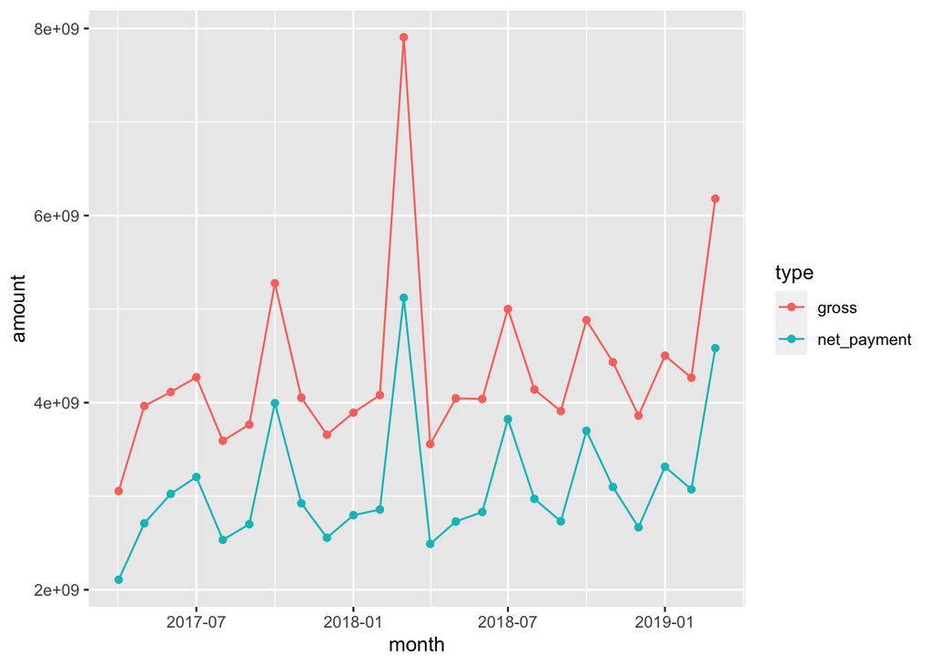

```r
# Trends for budget allocation over time
district_spending_exp_final %>%
    filter(demand_desc == "EDUCATION") %>%
    mutate(month = floor_date(transaction_date, unit = "month")) %>%
    group_by(month) %>%
    summarise(gross = sum(gross),
              net_payment = sum(net_payment)) %>%
    gather(type, amount, -month) %>%
    ggplot(aes(x = month, y = amount, color = type)) +
    geom_line() + geom_point()
```

###### **Top Districts & Treasuries**

```r
# District Wise spending
district_spending_exp_final %>%
    filter(demand_desc == "EDUCATION") %>%
    group_by(year, district) %>%
    summarise(net_payment = sum(net_payment)) %>%
    spread(year, net_payment, fill = 0) %>%
    arrange(desc(`2018-19`)) %>%
    mutate(`net_payment (2018-19)` = sum(`2018-19`),
           `net_payment (2017-18)` = sum(`2017-18`)) %>%
    mutate(`% of net_payment (2018-19)` = percent(`2018-19`/`net_payment (2018-19)`),
           `% of net_payment (2017-18)` = percent(`2017-18`/`net_payment (2017-18)`)) %>%
    select(district, `2018-19`, `% of net_payment (2018-19)`, `2017-18`, `% of net_payment (2017-18)`)
```

```
## # A tibble: 13 x 5
##    district        `2018-19` `% of net_payment (… `2017-18` `% of net_payment (…
##    <chr>               <dbl> <formttbl>               <dbl> <formttbl>
##  1 SHIMLA CAPITA… 6758700127 17.78%                  7.30e9 19.97%
##  2 DHARAMSALA     6222015458 16.37%                  5.76e9 15.77%
##  3 MANDI          5136877705 13.51%                  4.84e9 13.25%
##  4 SHIMLA         4401083706 11.58%                  4.17e9 11.41%
##  5 SOLAN          2556012217 6.72%                   2.38e9 6.51%
##  6 SIRMAUR        2540670247 6.68%                   2.36e9 6.46%
##  7 CHAMBA         2243848755 5.90%                   2.15e9 5.89%
##  8 HAMIRPUR       2153101953 5.66%                   1.99e9 5.46%
##  9 UNA            2114616661 5.56%                   1.98e9 5.41%
## 10 BILASPUR       1967252719 5.18%                   1.83e9 5.02%
## 11 KULLU          1917295850 5.04%                   1.78e9 4.87%
## 12 KINNAUR            344341 0.00%                   6.91e5 0.00%
## 13 LAHAUL AND SP…          0 0.00%                   2.70e5 0.00%
```

```r
# % of Every District's Spending
district_spending_exp_final %>%
    filter(year == "2018-19") %>%
    mutate(ed_flag = if_else(is.na(demand_desc) | demand_desc != "EDUCATION",
                             "OTHER", "EDUCATION")) %>%
    group_by(ed_flag, district) %>%
    summarise(net_payment = sum(net_payment)) %>%
    spread(ed_flag, net_payment, fill = 0) %>%
    mutate(percent_ed = percent(EDUCATION/(EDUCATION + OTHER))) %>%
    arrange(desc(EDUCATION))
```

```
## # A tibble: 14 x 4
##    district                 EDUCATION       OTHER percent_ed
##    <chr>                        <dbl>       <dbl> <formttbl>
##  1 SHIMLA CAPITAL TREASURY 6758700127 82639271089 7.56%
##  2 DHARAMSALA              6222015458 29432992981 17.45%
##  3 MANDI                   5136877705 24247604833 17.48%
##  4 SHIMLA                  4401083706 76086230820 5.47%
##  5 SOLAN                   2556012217 12921762123 16.51%
##  6 SIRMAUR                 2540670247 11506757055 18.09%
##  7 CHAMBA                  2243848755 11978893839 15.78%
##  8 HAMIRPUR                2153101953 10661110668 16.80%
##  9 UNA                     2114616661 11043897124 16.07%
## 10 BILASPUR                1967252719  8207145443 19.34%
## 11 KULLU                   1917295850  7713757531 19.91%
## 12 KINNAUR                     344341  3693984844 0.01%
## 13 LAHAUL AND SPITI                 0  2710385052 0.00%
## 14 NEW DELHI                        0    31980232 0.00%
```

```r
# Treasury Wise spending
district_spending_exp_final %>%
    filter(year == "2018-19") %>%
    mutate(ed_flag = if_else(is.na(demand_desc) | demand_desc != "EDUCATION",
                             "OTHER", "EDUCATION")) %>%
    group_by(ed_flag, treasury) %>%
    summarise(net_payment = sum(net_payment)) %>%
    spread(ed_flag, net_payment, fill = 0) %>%
    mutate(percent_ed = percent(EDUCATION/(EDUCATION + OTHER))) %>%
    arrange(desc(EDUCATION))
```

```
## # A tibble: 105 x 4
##    treasury          EDUCATION       OTHER percent_ed
##    <chr>                 <dbl>       <dbl> <formttbl>
##  1 CAPITAL TREASURY 6758700127 82639271089 7.56%
##  2 SHIMLA           1123800972 64968917352 1.70%
##  3 KULLU             995101804  6013867727 14.20%
##  4 CHAMBA            963020984  6453987033 12.98%
##  5 PALAMPUR          875057791  5390059808 13.97%
##  6 GHUMARWIN         814966623  1948719578 29.49%
##  7 AMB               801325277  2446698102 24.67%
##  8 NURPUR            677280314  2136746781 24.07%
##  9 KANGRA            669698550  3445083471 16.28%
## 10 MANDI             665708929 10443820152 5.99%
## # … with 95 more rows
```

```r
# Treasuries with Highest % Share in Education
district_spending_exp_final %>%
    filter(year == "2018-19") %>%
    mutate(ed_flag = if_else(is.na(demand_desc) | demand_desc != "EDUCATION",
                             "OTHER", "EDUCATION")) %>%
    group_by(ed_flag, treasury) %>%
    summarise(net_payment = sum(net_payment)) %>%
    spread(ed_flag, net_payment, fill = 0) %>%
    mutate(percent_ed = percent(EDUCATION/(EDUCATION + OTHER))) %>%
    arrange(desc(percent_ed))
```

```
## # A tibble: 105 x 4
##    treasury    EDUCATION     OTHER percent_ed
##    <chr>           <dbl>     <dbl> <formttbl>
##  1 KAMRAU      198088904  67523439 74.58%
##  2 KUPVI       103603680  39576206 72.36%
##  3 BHALIE      179053860  70484937 71.75%
##  4 DARLAGHAT   199901845  86770407 69.73%
##  5 RAKKAR      204312323  92348254 68.87%
##  6 DHEERA      115495007  55336801 67.61%
##  7 KHUNDIAN    148299648  74053842 66.70%
##  8 BALI CHOWKI 155167414  84745630 64.68%
##  9 NIHRI       103183589  56971627 64.43%
## 10 AUT         184486885 112654894 62.09%
## # … with 95 more rows
```

- Shimla Capital Treasury and Dharamsala have respectively 17.78% and 16.37% of all education spending expenditure.
- Treasuries like Kamrau, Kupvi and Bhalie have over 70% of their budget spending in education.

```r
# Major Expenditure
district_spending_exp_final %>%
    filter(demand_desc == "EDUCATION") %>%
    group_by(year, major_desc) %>%
    summarise(net_payment = sum(net_payment)) %>%
    spread(year, net_payment, fill = 0) %>%
    arrange(desc(`2018-19`)) %>%
    mutate(`Total net_payment (2018-19)` = sum(`2018-19`),
           `Total net_payment (2017-18)` = sum(`2017-18`)) %>%
    mutate(`% of net_payment (2018-19)` = percent(`2018-19`/`Total net_payment (2018-19)`),
           `% of net_payment (2017-18)` = percent(`2017-18`/`Total net_payment (2017-18)`)) %>%
    select(major_desc, `2018-19`, `% of net_payment (2018-19)`, `2017-18`, `% of net_payment (2017-18)`)
```

```
## # A tibble: 8 x 5
##   major_desc        `2018-19` `% of net_payment (… `2017-18` `% of net_payment …
##   <chr>                 <dbl> <formttbl>               <dbl> <formttbl>
## 1 GENERAL EDUCATI…    3.67e10 96.42%                 3.48e10 95.28%
## 2 CAPITAL OUTLAY …    1.11e 9 2.92%                  1.55e 9 4.24%
## 3 PUBLIC WORKS        1.68e 8 0.44%                  1.33e 8 0.36%
## 4 ART AND CULTURE     6.19e 7 0.16%                  2.75e 7 0.08%
## 5 LOANS FOR EDUCA…    2.00e 7 0.05%                  1.00e 7 0.03%
## 6 SOCIAL SECURITY…    1.73e 6 0.00%                  2.86e 6 0.01%
## 7 OTHER SOCIAL SE…    0.      0.00%                  1.28e 5 0.00%
## 8 WELFARE OF SCHE…    0.      0.00%                  2.13e 5 0.00%
```

```r
# Major Expenditure
district_spending_exp_final %>%
    filter(demand_desc == "EDUCATION" & major_desc == "GENERAL EDUCATION") %>%
    group_by(year, sub_major_desc) %>%
    summarise(net_payment = sum(net_payment)) %>%
    spread(year, net_payment, fill = 0) %>%
    arrange(desc(`2018-19`)) %>%
    mutate(`Total net_payment (2018-19)` = sum(`2018-19`),
           `Total net_payment (2017-18)` = sum(`2017-18`)) %>%
    mutate(`% of net_payment (2018-19)` = percent(`2018-19`/`Total net_payment (2018-19)`),
           `% of net_payment (2017-18)` = percent(`2017-18`/`Total net_payment (2017-18)`)) %>%
    select(sub_major_desc, `2018-19`, `% of net_payment (2018-19)`, `2017-18`, `% of net_payment (2017-18)`)
```

```
## # A tibble: 6 x 5
##   sub_major_desc      `2018-19` `% of net_payment … `2017-18` `% of net_payment…
##   <chr>                   <dbl> <formttbl>              <dbl> <formttbl>
## 1 ELEMENTARY EDUCAT…    1.99e10 54.28%                1.93e10 55.38%
## 2 SECONDARY EDUCATI…    1.33e10 36.37%                1.23e10 35.24%
## 3 UNIVERSITY AND HI…    3.11e 9 8.49%                 2.91e 9 8.37%
## 4 GENERAL               2.69e 8 0.73%                 3.08e 8 0.89%
## 5 LANGUAGE DEVELOPM…    4.30e 7 0.12%                 3.74e 7 0.11%
## 6 ADULT EDUCATION       0.      0.00%                 3.86e 6 0.01%
```

```r
# Sub-major Expenditure
# Elementary Education
district_spending_exp_final %>%
    filter(demand_desc == "EDUCATION" &
             major_desc == "GENERAL EDUCATION" &
             sub_major_desc == "ELEMENTARY EDUCATION") %>%
    group_by(year, minor_desc) %>%
    summarise(net_payment = sum(net_payment)) %>%
    spread(year, net_payment, fill = 0) %>%
    arrange(desc(`2018-19`)) %>%
    mutate(`Total net_payment (2018-19)` = sum(`2018-19`),
           `Total net_payment (2017-18)` = sum(`2017-18`)) %>%
    mutate(`% of net_payment (2018-19)` = percent(`2018-19`/`Total net_payment (2018-19)`),
           `% of net_payment (2017-18)` = percent(`2017-18`/`Total net_payment (2017-18)`)) %>%
    select(minor_desc, `2018-19`, `% of net_payment (2018-19)`, `2017-18`, `% of net_payment (2017-18)`)
```

```
## # A tibble: 7 x 5
##   minor_desc          `2018-19` `% of net_payment … `2017-18` `% of net_payment…
##   <chr>                   <dbl> <formttbl>              <dbl> <formttbl>
## 1 GOVERNMENT PRIMAR…    1.62e10 81.49%                1.57e10 81.66%
## 2 SARAV SHIKSHA ABH…    2.17e 9 10.92%                2.03e 9 10.52%
## 3 OTHER EXPENDITURE     8.86e 8 4.45%                 8.70e 8 4.51%
## 4 INSPECTION            4.06e 8 2.04%                 3.58e 8 1.86%
## 5 DIRECTION AND ADM…    1.14e 8 0.57%                 1.98e 8 1.03%
## 6 TEACHERS TRAINING     1.04e 8 0.52%                 7.87e 7 0.41%
## 7 ASSISTANCE TO NON…    1.33e 6 0.01%                 1.21e 6 0.01%
```

```r
# Secondary Education
district_spending_exp_final %>%
    filter(demand_desc == "EDUCATION" &
             major_desc == "GENERAL EDUCATION" &
             sub_major_desc == "SECONDARY EDUCATION") %>%
    group_by(year, minor_desc) %>%
    summarise(net_payment = sum(net_payment)) %>%
    spread(year, net_payment, fill = 0) %>%
    arrange(desc(`2018-19`)) %>%
    mutate(`Total net_payment (2018-19)` = sum(`2018-19`),
           `Total net_payment (2017-18)` = sum(`2017-18`)) %>%
    mutate(`% of net_payment (2018-19)` = percent(`2018-19`/`Total net_payment (2018-19)`),
           `% of net_payment (2017-18)` = percent(`2017-18`/`Total net_payment (2017-18)`)) %>%
    select(minor_desc, `2018-19`, `% of net_payment (2018-19)`, `2017-18`, `% of net_payment (2017-18)`)
```

```
## # A tibble: 5 x 5
##   minor_desc          `2018-19` `% of net_payment … `2017-18` `% of net_payment…
##   <chr>                   <dbl> <formttbl>              <dbl> <formttbl>
## 1 GOVERNMENT SECOND…    1.30e10 97.42%                1.19e10 96.79%
## 2 OTHER EXPENDITURE     1.32e 8 0.99%                 1.98e 8 1.62%
## 3 INSPECTION            1.04e 8 0.78%                 1.03e 8 0.84%
## 4 DIRECTION & ADMIN…    9.76e 7 0.73%                 8.98e 7 0.73%
## 5 ASSISTANCE TO NON…    1.03e 7 0.08%                 3.01e 6 0.02%
```

```r
# Minor Expenditure
# Elementary Education
district_spending_exp_final %>%
    filter(demand_desc == "EDUCATION" &
             major_desc == "GENERAL EDUCATION" &
             sub_major_desc == "ELEMENTARY EDUCATION" &
             minor_desc == "GOVERNMENT PRIMARY SCHOOLS") %>%
    group_by(year, sub_minor_desc) %>%
    summarise(net_payment = sum(net_payment)) %>%
    spread(year, net_payment, fill = 0) %>%
    arrange(desc(`2018-19`)) %>%
    mutate(`Total net_payment (2018-19)` = sum(`2018-19`),
           `Total net_payment (2017-18)` = sum(`2017-18`)) %>%
    mutate(`% of net_payment (2018-19)` = percent(`2018-19`/`Total net_payment (2018-19)`),
           `% of net_payment (2017-18)` = percent(`2017-18`/`Total net_payment (2017-18)`)) %>%
    select(sub_minor_desc, `2018-19`, `% of net_payment (2018-19)`, `2017-18`, `% of net_payment (2017-18)`)
```

```
## # A tibble: 4 x 5
##   sub_minor_desc       `2018-19` `% of net_payment… `2017-18` `% of net_payment…
##   <chr>                    <dbl> <formttbl>             <dbl> <formttbl>
## 1 EXPENDITURE ON EDUC…    8.92e9 55.04%                8.75e9 55.57%
## 2 MIDDLE SCHOOL [S00B]    7.28e9 44.92%                6.75e9 42.87%
## 3 EXPENDITURE ON URDU…    6.69e6 0.04%                 8.68e6 0.06%
## 4 ATAL VARDI YOJNA [S…    0.     0.00%                 2.37e8 1.50%
```

```r
# Secondary Education
district_spending_exp_final %>%
    filter(demand_desc == "EDUCATION" &
             major_desc == "GENERAL EDUCATION" &
             sub_major_desc == "SECONDARY EDUCATION" &
             minor_desc == "GOVERNMENT SECONDARY SCHOOLS") %>%
    group_by(year, sub_minor_desc) %>%
    summarise(net_payment = sum(net_payment)) %>%
    spread(year, net_payment, fill = 0) %>%
    arrange(desc(`2018-19`)) %>%
    mutate(`Total net_payment (2018-19)` = sum(`2018-19`),
           `Total net_payment (2017-18)` = sum(`2017-18`)) %>%
    mutate(`% of net_payment (2018-19)` = percent(`2018-19`/`Total net_payment (2018-19)`),
           `% of net_payment (2017-18)` = percent(`2017-18`/`Total net_payment (2017-18)`)) %>%
    select(sub_minor_desc, `2018-19`, `% of net_payment (2018-19)`, `2017-18`, `% of net_payment (2017-18)`)
```

```
## # A tibble: 11 x 5
##    sub_minor_desc        `2018-19` `% of net_paymen… `2017-18` `% of net_paymen…
##    <chr>                     <dbl> <formttbl>            <dbl> <formttbl>
##  1 SECONDARY SCHOOLS [S…   1.18e10 91.06%              1.08e10 90.90%
##  2 RASHTRYA MADHYAMIC S…   8.84e 8 6.80%               2.46e 8 2.07%
##  3 INFORMATION & COMMUN…   1.97e 8 1.52%               2.61e 8 2.20%
##  4 GIA TO SCHOOL MANAGE…   7.59e 7 0.58%               4.86e 7 0.41%
##  5 MEDHA PROTSAHAN YOJN…   3.50e 6 0.03%               0.      0.00%
##  6 TEACHER EDUCATION PR…   1.97e 5 0.00%               7.06e 7 0.59%
##  7 CHIEF MINISTER UNIFO…   0.      0.00%               8.27e 7 0.70%
##  8 EXPENDITURE ON INCLU…   0.      0.00%               4.09e 6 0.03%
##  9 MUKHYA MANTRI GIAN D…   0.      0.00%               5.00e 6 0.04%
## 10 STUDENT DIGITAL YOJN…   0.      0.00%               1.60e 8 1.35%
## 11 VACATIONALISATION OF…   0.      0.00%               2.02e 8 1.70%
```

- 96.42% of all net payments in education were towards General Education
- General Education net payments consists of Elementary (54.28%) & Secondary (36.37%)

###### **Statement of Expenditure**

```r
# Education Overall
district_spending_exp_final %>%
    filter(demand_desc == "EDUCATION") %>%
    group_by(year, soe_description) %>%
    summarise(net_payment = sum(net_payment)) %>%
    spread(year, net_payment, fill = 0) %>%
    arrange(desc(`2018-19`)) %>%
    mutate(`Total net_payment (2018-19)` = sum(`2018-19`),
           `Total net_payment (2017-18)` = sum(`2017-18`)) %>%
    mutate(`% of net_payment (2018-19)` = percent(`2018-19`/`Total net_payment (2018-19)`),
           `% of net_payment (2017-18)` = percent(`2017-18`/`Total net_payment (2017-18)`)) %>%
    select(soe_description, `2018-19`, `% of net_payment (2018-19)`, `2017-18`, `% of net_payment (2017-18)`)
```

```
## # A tibble: 22 x 5
##    soe_description     `2018-19` `% of net_payment… `2017-18` `% of net_payment…
##    <chr>                   <dbl> <formttbl>             <dbl> <formttbl>
##  1 SALARIES              2.95e10 77.72%               2.74e10 74.96%
##  2 GIA GENERAL (Salar…   3.66e 9 9.64%                3.93e 9 10.77%
##  3 GIA GENERAL (Non-S…   1.36e 9 3.58%                6.13e 8 1.68%
##  4 MAJOR WORKS           1.10e 9 2.90%                1.55e 9 4.24%
##  5 MATERIAL AND SUPPLY   6.46e 8 1.70%                6.82e 8 1.87%
##  6 WAGES                 3.52e 8 0.93%                3.71e 8 1.01%
##  7 SCHOLARSHIPS STIPE…   2.67e 8 0.70%                3.42e 8 0.93%
##  8 HONORARIUM            2.40e 8 0.63%                2.11e 8 0.58%
##  9 MEDICAL REIMBURSEM…   2.16e 8 0.57%                2.10e 8 0.58%
## 10 MAINTENANCE           1.68e 8 0.44%                1.33e 8 0.36%
## # … with 12 more rows
```

~78% of District spending expenditure is towards direct salries.